# NAVDAT Transmitter

Developed by Konovalov Vitaly (vskonovalov@inbox.ru) for Central Scientific Research Institute "Kurs", 2020 г.

This document describes the developed model of the NAVDAT transmitter. Recommendation ITU-R M.2010 (01/2019) [1] was used as the main description of the protocol.

Recommendation ITU-R M.2010 is based on the DRM standard and, unfortunately, not completely describes all the details of the NAVDAT system. In this document, I tried to compile information from both standards, but sometimes I was unable to find details. These parts are marked as **Judgement calls** and describes the details of how and why I made the following decisions. They could be wrong, though.

Furthermore, this document describes modulation, pilots and streams insertion and symbol composition, but not the coding.

## Modulation

NAVDAT protocol uses 3 types of modulation (QAM4, QAM16 и QAM64) for data signals and BPSK for pilot signals. According to the documentation, different streams could be modulated differently, see the following table:

| Stream | Length (bits) | QAM4 | QAM16 | QAM64 |
| --- | --- | --- | --- | --- |
| MIS | 14 | + |  |  |
| TIS | 63 | + | + |  |
| DATA | 48 - 32816 | + | + | + |

> **Judgement call:** TIS stream has 63 bits length, which is not divisible by modulation size of QAM4 or QAM16 without a remainder. To handle this I assume virtual 64th bit of TIS stream always be 0.

NAVDAT documentation [1] does not describes modulation of signal completely, so, according to the DRM documentation [2, clause 7.4, p. 105 & clause 8.4.2.2, p. 120], we have following normalization factors:

- For 64-QAM, the normalization factor is **a = 1/sqrt(42)**.
- For 16-QAM, the normalization factor is **a = 1/sqrt(10)**.
- For 4-QAM, the normalization factor is **a = 1/sqrt(2)**.
- For robustness modes A, B, C and D, all frequency reference cells should have the power gain of 2, i.e. **a = sqrt(2)**

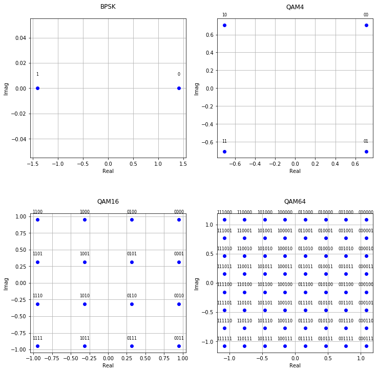

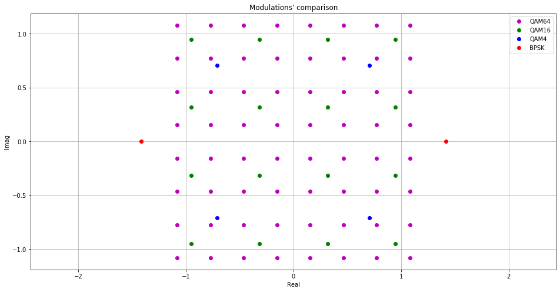

## Symbols generation

### Pilot-signals

NAVDAT documentation [1] describes pilots only for 229 subcarrier mode, although it turned out that all other modes are incorporated in this mode. DRM standard [2] confirms it.

#### Pilot-signal positions

According to section *Gain references* of the DRM documentation [2, clause 8.4.4, p. 124, table 58, mode B] pilot-signals' positions could be calculated with:

\begin{equation*} k = 1 + 2 × (s \mod 3) + 6 × p \end{equation*}

where s - the symbol number (from 1 to 14, symbol 0 is the header), p - integer number. The results of pilot positions calculation for all subcarrier modes are shown below:

```
Pilots in mode 23
Symbol 1: [-9, -3, 3, 9]
Symbol 2: [-7, -1, 5, 11]
Symbol 3: [-11, -5, 1, 7]

Pilots in mode 69
Symbol 1: [-33, -27, -21, -15, -9, -3, 3, 9, 15, 21, 27, 33]
Symbol 2: [-31, -25, -19, -13, -7, -1, 5, 11, 17, 23, 29]
Symbol 3: [-29, -23, -17, -11, -5, 1, 7, 13, 19, 25, 31]

Pilots in mode 115
Symbol 1: [-57, -51, -45, -39, -33, -27, -21, -15, -9, -3, 3, 9, 15, 21, 27, 33, 39, 45, 51, 57]
Symbol 2: [-55, -49, -43, -37, -31, -25, -19, -13, -7, -1, 5, 11, 17, 23, 29, 35, 41, 47, 53]
Symbol 3: [-53, -47, -41, -35, -29, -23, -17, -11, -5, 1, 7, 13, 19, 25, 31, 37, 43, 49, 55]

Pilots in mode 229
Symbol 1: [-111, -105, -99, -93, -87, -81, -75, -69, -63, -57, -51, -45, -39, -33, -27, -21, -15, -9, -3, 3, 9, 15, 21, 27, 33, 39, 45, 51, 57, 63, 69, 75, 81, 87, 93, 99, 105, 111]
Symbol 2: [-109, -103, -97, -91, -85, -79, -73, -67, -61, -55, -49, -43, -37, -31, -25, -19, -13, -7, -1, 5, 11, 17, 23, 29, 35, 41, 47, 53, 59, 65, 71, 77, 83, 89, 95, 101, 107, 113]
Symbol 3: [-113, -107, -101, -95, -89, -83, -77, -71, -65, -59, -53, -47, -41, -35, -29, -23, -17, -11, -5, 1, 7, 13, 19, 25, 31, 37, 43, 49, 55, 61, 67, 73, 79, 85, 91, 97, 103, 109]
```

#### Pilot-signal amplitude

Section *Gain references* of DRM standard [2] describes the additional gain of pilots on edges of the spectrum, however, NAVDAT documentation [1] never mentions it. So we use information from section *Frequency references* for pilot amplitude value:

- For robustness modes A, B, C and D, all frequency reference cells should have the power gain of 2, i.e. **a = sqrt(2)**

#### Pilot-signal phase

NAVDAT documentation [1, annex 3, section 1.6, table 3] describes the pilot phase sequence but does not describe how it should be mapped into pilot carriers. DRM standard also describes the calculation of pilots phases [2, clause 8.4.4.3, p. 125], however, values of pilot phase sequences from NAVDAT do not correspond with DRM formulas.

> **Judgement call:** Here I implement the most simple solution: phases are generated cyclically from the pilot phase sequence, starting from the lowest negative subcarriers of the first symbol to the highest positive subcarriers of the last one. I assume that this method is wrong because it looks like the pilot-signal phases of lower subcarrier modes should be the subset of 229 subcarrier mode.

### Stream mapping in frame

NAVDAT documentation describes the order of MIS, TIS and DS streams in a frame, but does not describe the cells in frame assigned for each stream. On the other hand, DRM documentation [2] give us details on how it's streams are mapped to the frames. Moreover, there is the following similarity between DRM and NAVDAT streams:

| NAVDAT | DRM |
| --- | --- |
| MIS | FAC |
| TIS | SDC |
| DS | MSC |

However, it is only a similarity. In these standards streams have different data sizes and symbol occupancy, so we cannot just implement the DRM scheme.

#### MIS

MIS contains data about frame modulation and spectrum occupancy. MIS is always modulated with QAM4 and consists of 14 bits [1], which means it always occupies 7 cells. To simplify the extraction of data about frame spectrum, MIS should occupy subcarriers available in all spectrum occupancy modes (from -11 to 11).

In DRM stream FAC occupies lowest positive subcarriers [2, clause 8.3, p. 118], shared by all the spectrum occupancy modes. However, it is implemented that way because in DRM some spectrum modes are asymmetrical relative to the carrier frequency, so it is not mandatory.

> **Judgement call:** I assume that for the MIS field it is possible to choose any cell from the 18 not pilot cells of the first symbol. To follow the DRM analog, here I use subcarriers 1, 2, 4, 5, 6, 7 and 8.

#### TIS

TIS contains data about the transmitter, time and DS coding. TIS is modulated with either QAM4 or QAM16 and always consists of 63 bits [1]. Depending on modulation TIS occupies either 16 or 32 cells.

> **Judgement call:** There is no need to map TIS into certain cells like MIS. Moreover, for different spectrum occupancies and modulations, TIS could occupy a different number of symbols. Thus TIS is mapped to the cells unused by pilots and MIS, starting from the lowest negative subcarriers of the first symbol.

#### DS

According to the [2, clause 8.6 & 7.7, p. 133 & 114] the DS is mapped to the unused cells of the lowest subcarriers of the first symbol to the highest positive subcarriers of the last symbol.

Below the representation of stream mapping is given:

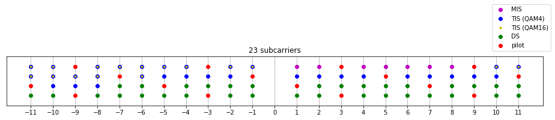

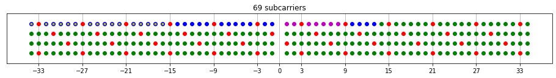

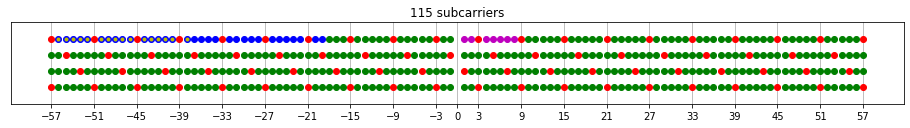

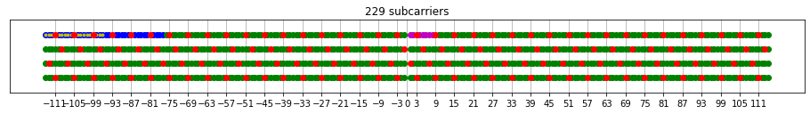

## FFT and Guard Interval

According to the information from [2, clause 4.4.2.2, p. 17, table 2 (mode A)] FFT size should be 288 and guard interval size - 32 samples. The period of samples is (83+1/3) us. From this information we can calculate distance between sybcarriers:

\begin{equation*} \Delta f = \frac{Fs}{N} \end{equation*}

where *Δf* - distance between subcarriers, *Fs* - sample frequency and *N* - FFT size. [[3](https://dsp.stackexchange.com/questions/17801/how-to-calculate-bandwidth-require-for-ofdm)]

```
Distance between subcarriers: 41.667 Hz
Sample frequency: 12.0 KHz
```

These values meet the values of distance between subcarriers from [1, annex 3, clause 1.3]. So the sampling frequency is 12 kHz.

For power normalization, the signal after FFT is divided by square root of *N*.

On the diagrams below the results of the translation frame to the time domain are given.

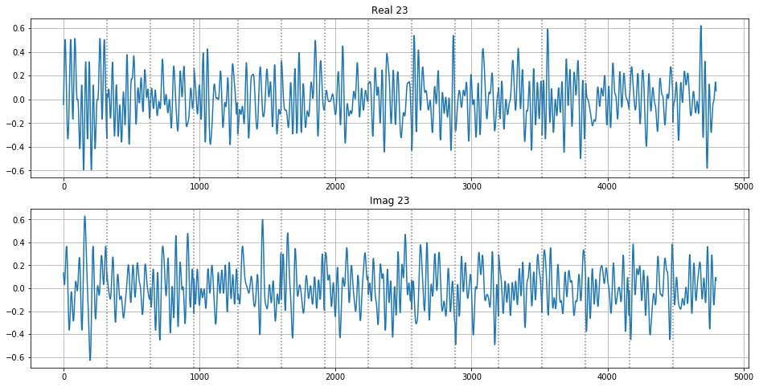

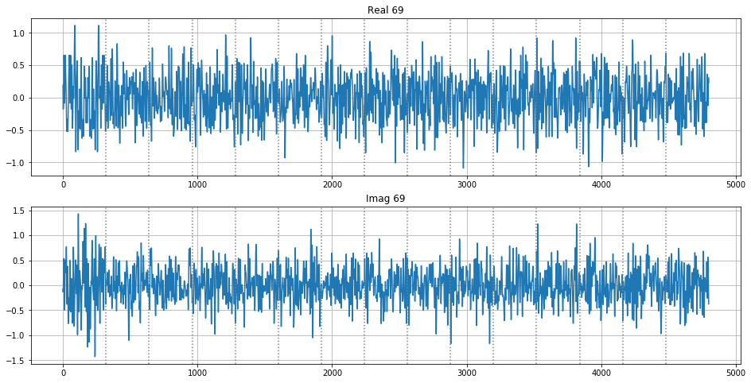

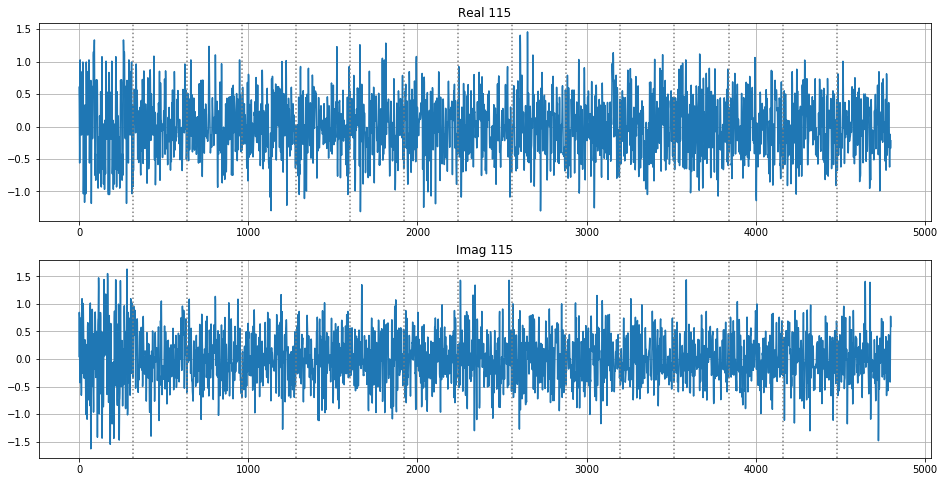

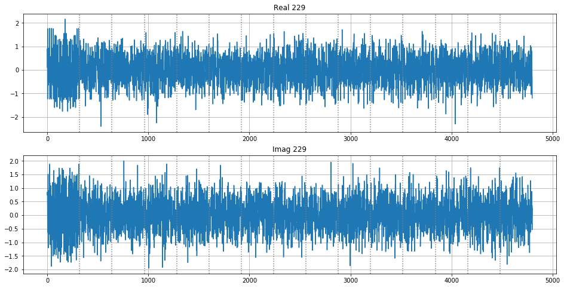

## Used links and resources

1. [Recommendation ITU-R M.2010-1 (01/2019)](https://www.itu.int/dms_pubrec/itu-r/rec/m/R-REC-M.2010-1-201901-I!!PDF-E.pdf)
2. [ES 201 980 - V4.1.1 - Digital Radio Mondiale (DRM); System Specification](https://www.etsi.org/deliver/etsi_es/201900_201999/201980/04.01.01_60/es_201980v040101p.pdf)
3. [dsp.stackexchange.com, question 17801](https://dsp.stackexchange.com/questions/17801/how-to-calculate-bandwidth-require-for-ofdm)